# Women Entrepreneurship by Country

Adriana Picoral

12/1/2020

# Introduction

In this paper, I will discuss the effect of having women entrepreneurs on a country’s economy.

# Methods

My research question is as follows:

1. What is the relationship of having more entrepreneurs in a country (no matter the gender) and that country’s economy?
2. What is the relationship of having more women entrepreneurs in a country and that country’s economy?
3. Do women entrepreneurs have a greater impact in the economy than just entrepreneurs in general?

## Data

The data I am using was obtained from [Kaggle](https://www.kaggle.com/babyoda/women-entrepreneurship-and-labor-force) and contains the following variables: no, country, level_of_development, european_union_membership, currency, women_entrepreneurship_index, entrepreneurship_index, inflation_rate, female_labor_force_participation_rate. The data was collected in 2015 for 51 countries.

# Analysis

The two variables we have available on economic development for each country: a binary variable called *level_of_development* (i.e., Developed vs. Developing) and *inflation_rate*. The first step in the analysis is to establish whether inflation rate is lower or higher for developed countries, assuming that developed countries have better economies.

The box plot below shows that *developed* countries have a lower inflation rate than *developing* countries. Thus, we will assume that the lower the inflation rate, the stronger the country’s economy.

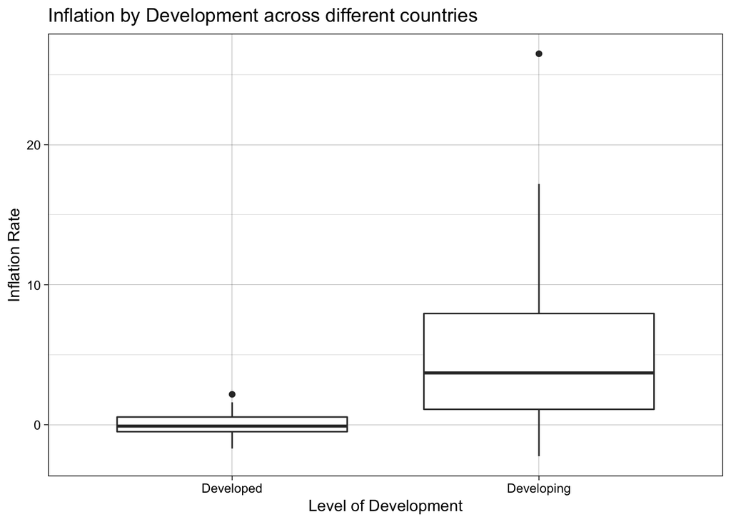

To answer my first research question (i.e., *What is the relationship of having more entrepreneurs in a country (no matter the gender) and that country’s economy?*), we need to establish the relationship between inflation and entrepreneurship index.

The scatter plot below shows that inflation rate has a negative relationship with entrepreneurship index. As entrepreneurship increases, inflation rate decreases. We can infer that having a high index for entrepreneurship (i.e., a lot of people owning business) is good for a country’s economy.

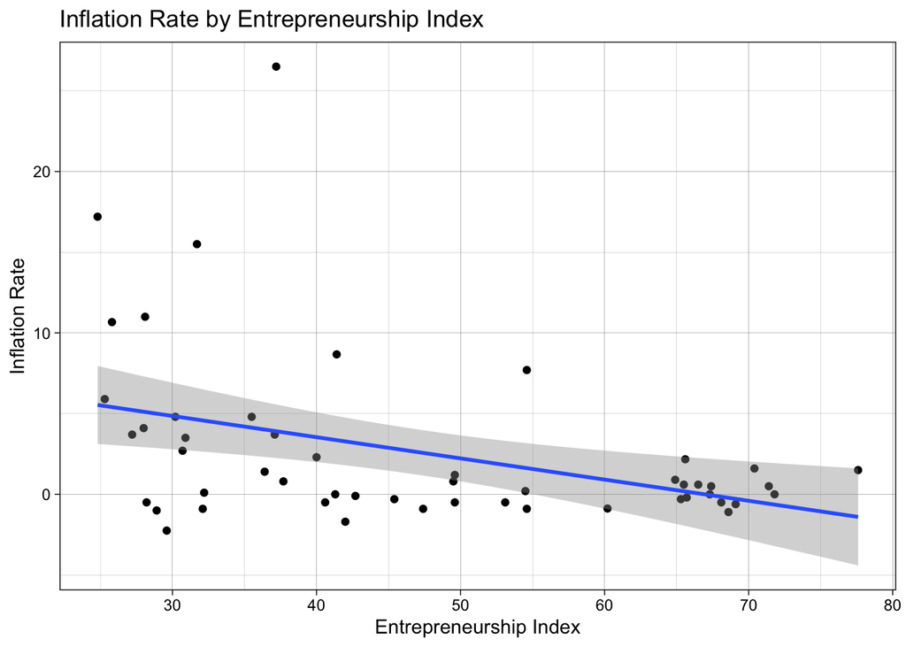

The table below shows the results of the linear regression (i.e., inflation rate by entrepreneurship index). As shown in both the plot above and the table below, the relationship between inflation and entrepreneurship is negative, with inflation going down by -0.13 point for each additional point in Entrepreneurship. The linear regression model for this relationship explains 14% of the variation in the data.

|  | Estimate | Std. Error | t value | Pr(>\|t\|) |
| --- | --- | --- | --- | --- |
| (Intercept) | 8.793863 | 2.1751516 | 4.042874 | 0.0001862 |
| entrepreneurship_index | -0.131373 | 0.0436008 | -3.013090 | 0.0040851 |

To answer my second research question (i.e., *What is the relationship of having more women entrepreneurs in a country and that country’s economy?*), we need to establish the relationship between inflation and women entrepreneurship index.

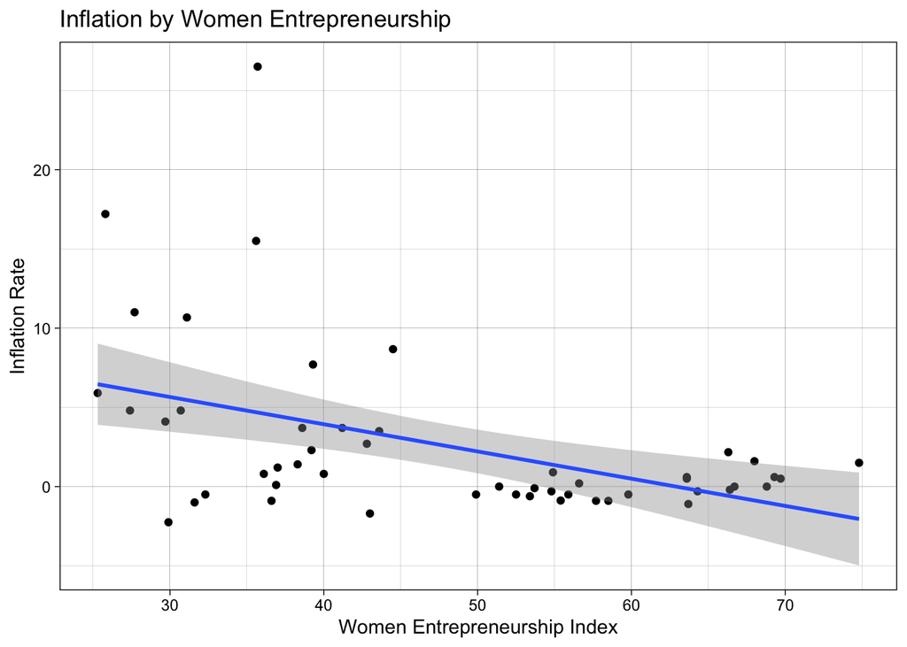

The table below shows that the relationship between inflation and women entrepreneurship is negative. Inflation goes down by -0.17 for every point increase in women entrepreneurship index. The model explains 19% of the variance.

|  | Estimate | Std. Error | t value | Pr(>\|t\|) |
| --- | --- | --- | --- | --- |
| (Intercept) | 10.8048470 | 2.3920152 | 4.517048 | 0.0000396 |
| women_entrepreneurship_index | -0.1717811 | 0.0479573 | -3.581957 | 0.0007823 |

Finally, to answer my third question (i.e., *Do women entrepreneurs have a greater impact in the economy than just entrepreneurs in general?*). Since the estimate for the impact on inflation rate by women entrepreneurship is higher than just entrepreneurship, and the variance explained is also higher, we can say that women entrepreneurs have a greater impact in the economy than just entrepreneurs in general.